# ML practice 7: Ансамбли

Сегодня мы продолжим знакомство с алгоритмами для регрессии и классификации. А точнее, поговорим о том, как объединять результаты нескольких моделей.

Начнем с двух популярных алгоритмов, которые основаны на объединении нескольких моделей в одну

И экспериментироать будем на уже рассматриваемой раньше задаче регрессии в датасете Boston.

Подготовим тренировочную и тестовую выборки:

```r
library(MASS)
set.seed(1)
train_ind = sample(1:nrow(Boston), nrow(Boston)*0.7)
boston.test=Boston[-train_ind,]
boston.train=Boston[train_ind,]
```

# Random forest

Первый алгоритм – это *Random Forest*, т.е. объединение деревьев

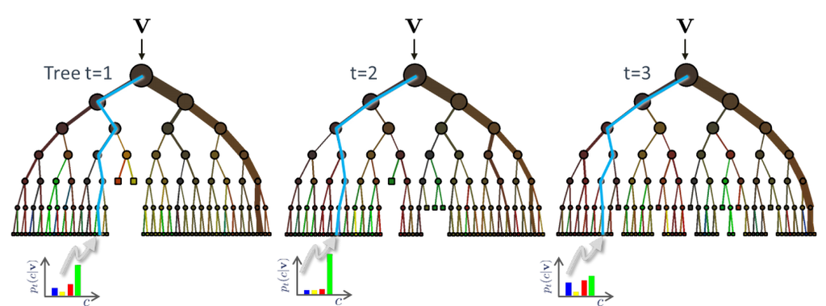

```r
library(randomForest)
set.seed(1)
bag.boston=randomForest(medv~.,data=boston.train, mtry=13, importance=TRUE)
yhat.bag = predict(bag.boston,newdata=boston.test)
```

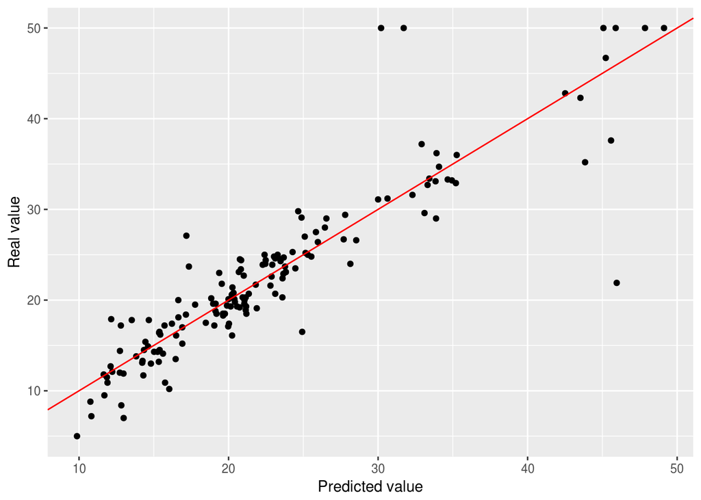

```r
library(ggplot2)
ggplot() + geom_point(aes(x=yhat.bag, y=boston.test$medv))+geom_abline(slope=1, intercept = 0, color="red") +
  xlab("Predicted value") + ylab("Real value")
```

Ошибка:

```r
mean((yhat.bag-boston.test$medv)^2)
```

```
## [1] 15.5015
```

Попробум другие параметры (`?randomForest`): `ntree` – number of trees to grow

```r
set.seed(1)
bag.boston=randomForest(medv~., data=boston.train, mtry=13,ntree=25)
yhat.bag = predict(bag.boston,newdata=boston.test)
mean((yhat.bag-boston.test$medv)^2)
```

```
## [1] 17.02849
```

```r
set.seed(1)
bag.boston=randomForest(medv~., data=boston.train, mtry=13, ntree=2500)
yhat.bag = predict(bag.boston,newdata=boston.test)
mean((yhat.bag-boston.test$medv)^2)
```

```
## [1] 15.43865
```

Почему считается дольше?

- `mtry` – number of variables randomly sampled as candidates at each split
- `importance` – should importance of predictors be assessed

```r
set.seed(1)
rf.boston=randomForest(medv~., data=boston.train, mtry=6, importance=TRUE)
yhat.rf = predict(rf.boston,newdata=boston.test)
mean((yhat.rf-boston.test$medv)^2)
```

```
## [1] 11.95628
```

Стало лучше, возможно мы немного побороли переобучение. А сравните, пожалуйста, ошибки на обучающей выборке для двух случаев.

Отметим, что в *Random Forest* у нас еще есть и автоматическая оценка важности параметров (признаков) – т.е. какой признак вносит больший вклад в модель. `IncMSE` = Increased MSE. Согласно справке – mean decrease in accuracy (MSE в случае регрессии), т.е. насколько удаление этой переменной ухудшит модель, увеличив MSE (для каждого дерева в лесе)

- Какая переменная важнее? С большим значением коэффициента или с меньшим?

```r
importance(rf.boston)
```

```
##           %IncMSE IncNodePurity
## crim    12.391084     1212.2606
## zn       4.125007       69.7680
## indus   10.877000     1487.8325
## chas     2.209171       84.3306
## nox     14.910835     1577.4581
## rm      38.081714    10398.9971
## age     11.833795      910.7594
## dis     15.752856     1806.3640
## rad      3.593166      139.4829
## tax     10.916379      495.6195
## ptratio 12.138230     1322.4922
## black    7.138717      491.6048
## lstat   28.596277     9392.6938
```

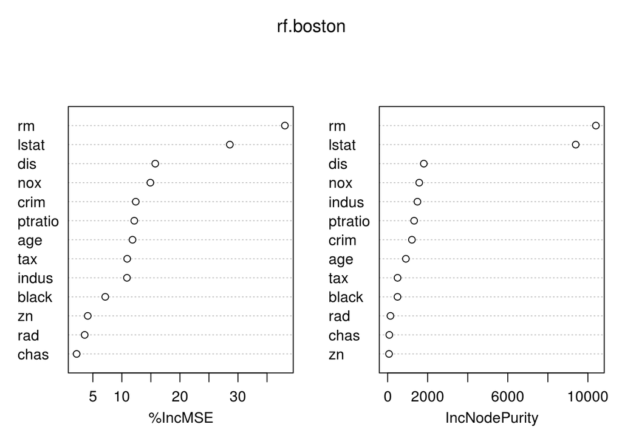

```r
varImpPlot(rf.boston)
```

Давайте попробуем удалить переменную из начала и из конца списка.

Ошибка на обучающей выборке на полной модели

```r
yhat.rf0 = predict(rf.boston,newdata=boston.train)
mean((yhat.rf0-boston.train$medv)^2)
```

```
## [1] 2.0145
```

Начало списка: `rm`

```r
set.seed(1)
rf.boston2=randomForest(medv~.-rm, data=boston.train, mtry=6, importance=TRUE)
yhat.rf2 = predict(rf.boston2,newdata=boston.train)
mean((yhat.rf2-boston.train$medv)^2)
```

```
## [1] 3.06567
```

Конец списка: `chas`

```r
set.seed(1)
rf.boston3=randomForest(medv~.-chas, data=boston.train, mtry=6, importance=TRUE)
yhat.rf3 = predict(rf.boston3,newdata=boston.train)
mean((yhat.rf3-boston.train$medv)^2)
```

```
## [1] 1.891246
```

- Какие выводы можно сделать?

Как обычно, метод можно вызывать с помощью пакета `caret`, но он проводит оптимизацию параметров, что увеличивает время работы https://topepo.github.io/caret/available-models.html

```r
library(caret)
set.seed(1)
#rf = train(medv~., data=boston.train, method = "rf")
rf = train(medv~., data=boston.train, method = "rf", tuneGrid = expand.grid(mtry = 6), importance = T)
rf
```

```
## Random Forest
##
## 354 samples
##  13 predictors
##
## No pre-processing
## Resampling: Bootstrapped (25 reps)
## Summary of sample sizes: 354, 354, 354, 354, 354, 354, ...
## Resampling results:
##
##   RMSE     Rsquared   MAE
##   3.42762  0.8619784  2.33442
##
## Tuning parameter 'mtry' was held constant at a value of 6
```

Так же можно получить оценку важности признаков

```r
importance(rf$finalModel)
```

```
##           %IncMSE IncNodePurity
## crim    13.098168    1247.41034
## zn       4.635447      79.68669
## indus   10.735212    1274.45732
## chas     2.515474      67.17616
## nox     15.561228    1629.04721
## rm      36.980602   10007.69796
## age     12.153106     775.71376
## dis     17.657109    1900.67886
## rad      4.629857     133.19835
## tax      9.534600     580.63779
## ptratio 13.397488    1383.09119
## black    7.852729     473.06431
## lstat   29.887834    9827.07190
```

И предсказать значения

```r
pred.rf = predict(rf, newdata = boston.test)
mean((pred.rf-boston.test$medv)^2)
```

```
## [1] 11.43452
```

# Boosting

Второй метод – это градиентный бустинг. На каждом следующем шаге пытаемся предсказать ошибочно предсказанные значения (классификация) или наиболее отдаленные предсказания – предсказываем остатки (регрессия)

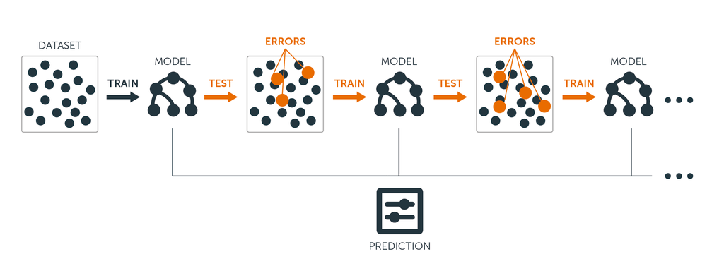

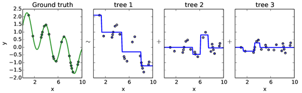

С точки знения интерфейса он почти не отличается от *Random Forest*

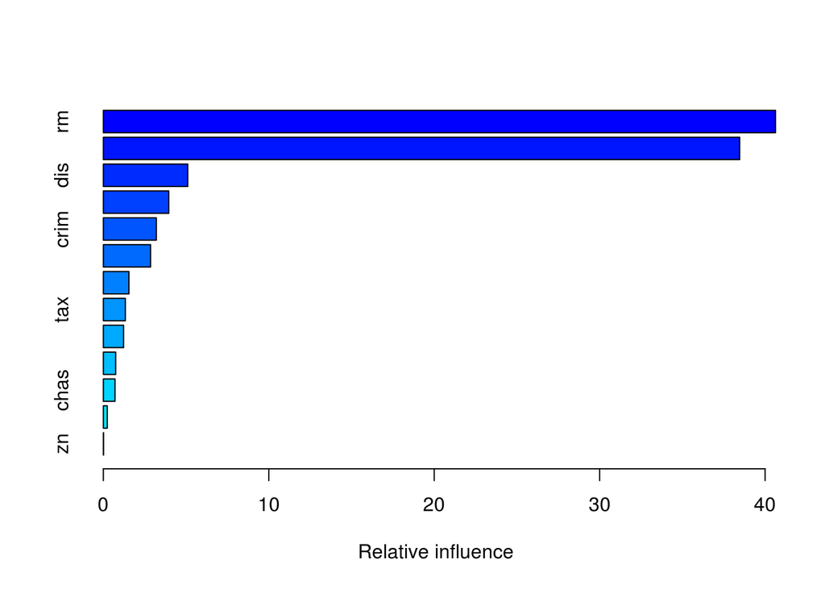

```
##             var     rel.inf
## rm           rm 40.62875474
## lstat     lstat 38.46406208
## dis         dis  5.09997240
## nox         nox  3.95581320
## crim       crim  3.20222641
## ptratio ptratio  2.85448521
## age         age  1.54505358
## tax         tax  1.32980906
## black     black  1.22246676
## indus     indus  0.74525854
## chas       chas  0.70483445
## rad         rad  0.23593323
## zn           zn  0.01133033
```

```r
library(gbm)
set.seed(1)
boost.boston=gbm(medv~., data=boston.train, distribution="gaussian", n.trees=5000, interaction.depth=4)
summary(boost.boston)
```

Посмотрим на прогноз.

```r
yhat.boost=predict(boost.boston,newdata=boston.test, n.trees=5000)
mean((yhat.boost-boston.test$medv)^2)
```

```
## [1] 12.81534
```

И сравним несколько моделей с разными параметрами (`?gbm` для объяснения параметров).

- distribution=“gaussian” – для регрессии
- distribution=“bernoulli” – для бинарной классификации

```r
boost.boston=gbm(medv~.,data=boston.train, distribution="gaussian", n.trees=5000,
                 interaction.depth=2, shrinkage=0.2, verbose=F)

yhat.boost=predict(boost.boston,newdata=boston.test, n.trees=5000)
mean((yhat.boost-boston.test$medv)^2)
```

```
## [1] 13.16424
```

Метод тоже можно вызывать с помощью пакета `caret` https://topepo.github.io/caret/available-models.html

```r
set.seed(1)
#boost = train(medv~., data=boston.train, method = "gbm")
boost = train(medv~., data=boston.train, method = "gbm", verbose = F)
boost
```

```
## Stochastic Gradient Boosting
##
## 354 samples
##  13 predictors
##
## No pre-processing
## Resampling: Bootstrapped (25 reps)
## Summary of sample sizes: 354, 354, 354, 354, 354, 354, ...
## Resampling results across tuning parameters:
##
##   interaction.depth  n.trees  RMSE      Rsquared   MAE
##   1                   50      4.192263  0.7950256  2.909607
##   1                  100      3.921266  0.8149944  2.684565
##   1                  150      3.844034  0.8223204  2.629220
##   2                   50      3.854333  0.8221014  2.631089
##   2                  100      3.668449  0.8376575  2.512600
##   2                  150      3.595099  0.8443281  2.488952
##   3                   50      3.726084  0.8328571  2.521926
##   3                  100      3.600198  0.8437483  2.459598
##   3                  150      3.558428  0.8477727  2.457404
##
## Tuning parameter 'shrinkage' was held constant at a value of 0.1
##
## Tuning parameter 'n.minobsinnode' was held constant at a value of 10
## RMSE was used to select the optimal model using  the smallest value.
## The final values used for the model were n.trees = 150,
##  interaction.depth = 3, shrinkage = 0.1 and n.minobsinnode = 10.
```

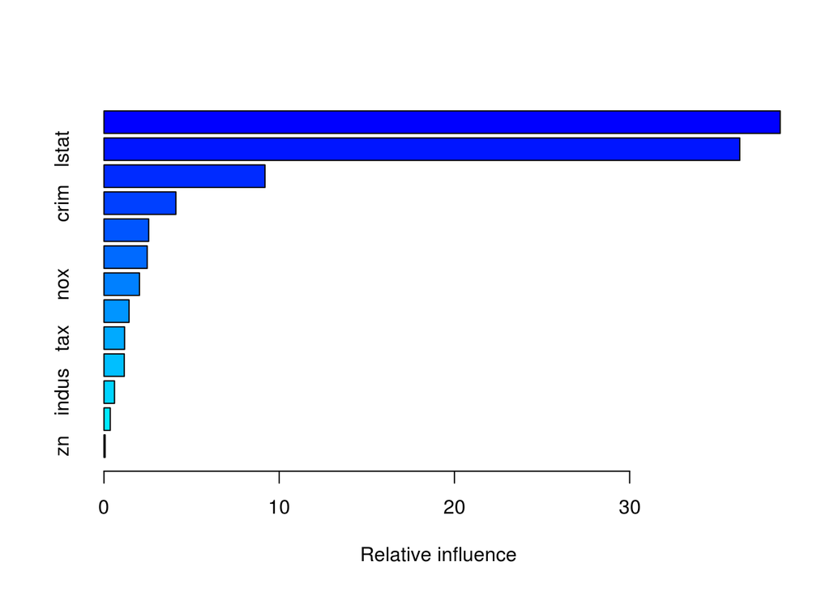

```
##             var     rel.inf
## rm           rm 38.59288139
## lstat     lstat 36.28502350
## dis         dis  9.19010918
## crim       crim  4.10266301
## ptratio ptratio  2.54998519
## age         age  2.46765029
## nox         nox  2.02523752
## black     black  1.42970379
## tax         tax  1.17418764
## chas       chas  1.15745522
## indus     indus  0.60023604
## rad         rad  0.35803521
## zn           zn  0.06683202
```

```r
summary(boost$finalModel)
```

Предсказание

```r
pred.gbm = predict(boost, newdata = boston.test)
mean((pred.gbm-boston.test$medv)^2)
```

```
## [1] 12.17758
```

# Ансамбли: общее описание

Ансамбли моделей не ограничиваются готовыми алгоритмами, модели можно соединять разными способами. Выделяют несколько подходов

1. Voting/averaging – голосование (классификация) / усреднение (регрессия) результатов нескольких моделей
2. Bagging (Bootstrap AGregation) – выделение случайных подвыборок с повторением, построение моделей (обычно одного типа) на каждой из них, объединение результатов. Random Forest – один из примеров
3. Boosting – на каждом новом шаге построение новой модели (обычно одного типа) для улучшения предсказания той части, которая неправильно предсказалась на предыдущем шаге. Один из примеров – градиентный бустинг
4. Stacking – построение нескольких моделей (обычно разного типа), затем построение обобщающей модели, в которую в качестве признаков (предикторов) передаются результаты первоначальных моделей

## Averaging

Построим три модели: дерево, линейную регрессию и регрессию с регуляризацией

```r
trC = trainControl(method = "cv", number = 10)
model.1.tree = train(medv~., data=boston.train, method = "ctree", trControl = trC)
pred.1.tree = predict(model.1.tree, newdata = boston.test)
mean((pred.1.tree - boston.test$medv)^2)
```

```
## [1] 20.54185
```

```r
model.2.lm = train(medv~., data=boston.train, method = "lm", trControl = trC)
pred.2.lm = predict(model.2.lm, newdata = boston.test)
mean((pred.2.lm - boston.test$medv)^2)
```

```
## [1] 28.65172
```

```r
model.3.reg = train(medv~., data=boston.train, method = "glmnet", trControl = trC)
pred.3.reg = predict(model.3.reg, newdata = boston.test)
mean((pred.3.reg - boston.test$medv)^2)
```

```
## [1] 28.45808
```

Результаты на обучающей выборке

```r
results = resamples(list(tree = model.1.tree, lm = model.2.lm, reg = model.3.reg))
summary(results)
```

```
##
## Call:
## summary.resamples(object = results)
##
## Models: tree, lm, reg
## Number of resamples: 10
##
## MAE
##          Min.  1st Qu.   Median     Mean  3rd Qu.     Max. NA's
## tree 2.464951 2.794427 2.938891 2.961188 3.142586 3.555397    0
## lm   2.577422 2.813693 3.206966 3.334373 3.805903 4.313447    0
## reg  2.681743 3.032268 3.259930 3.308533 3.520059 4.129965    0
##
## RMSE
##          Min.  1st Qu.   Median     Mean  3rd Qu.     Max. NA's
## tree 3.043034 3.591487 3.943169 4.261463 4.347883 6.256121    0
## lm   3.229714 3.901910 4.133899 4.555671 5.119348 6.358631    0
## reg  3.667796 4.143004 4.332401 4.591592 4.801210 6.675220    0
##
## Rsquared
##           Min.   1st Qu.    Median      Mean   3rd Qu.      Max. NA's
## tree 0.5845440 0.7856710 0.8121314 0.7874184 0.8299141 0.9001346    0
## lm   0.5696149 0.7235952 0.7861093 0.7637367 0.8151331 0.8779635    0
## reg  0.6223180 0.7206574 0.7773583 0.7537557 0.7897707 0.8466147    0
```

Итоговое предсказание на тестовой выборке

```r
pred.final = (pred.1.tree + pred.2.lm + pred.3.reg)/3
mean((pred.final - boston.test$medv)^2)
```

```
## [1] 21.53325
```

## Bagging

На каждом шаге случайно выбираем значения и строим модель

```r
sample(1:5, replace = T)
```

```
## [1] 1 4 5 3 5
```

```r
sample(1:5, replace = F)
```

```
## [1] 2 4 3 5 1
```

```r
d = matrix(NA, nrow = 10, ncol = dim(boston.test)[1]) #сюда будем сохранять предсказания
num = dim(boston.train)[1]
for (i in 1:10){
  s = sample(1:num, replace = T)
  data0 = boston.train[s,]
  model = train(medv~., data=data0, method = "glmnet", trControl = trC)
  d[i,] = predict(model, newdata = boston.test)
}
```

Предсказание

```r
pred.bag = colMeans(d)
mean((pred.bag - boston.test$medv)^2)
```

```
## [1] 28.66062
```

В `caret` есть реализованные ансамбли, построенные по такому принципу – см. `treebag`, `bagEarth`

## Boosting

Тоже можно реализовать вручную, но есть много уже готовых метдов, например, adaboost для классификации

## Stacking

Рассмотрим те же модели, что были построены для пункта Averaging. И в качестве обобщающей модели возьмем дерево

Создаем новый датасет

```r
dataStack = data.frame(tree = predict(model.1.tree, newdata = boston.train),
                       lm = predict(model.2.lm, newdata = boston.train),
                       reg = predict(model.3.reg, newdata = boston.train),
                       medv = boston.train$medv)
```

Строим модель

```r
model.tree = train(medv~., data=dataStack, method = "ctree")
```

Т.к. модель использует предсказания предыдущих моделей, то для тестовой выборки их тоже нужно посчитать (мы это уже делали раньше)

```r
dataStack.test = data.frame(tree = pred.1.tree, lm = pred.2.lm, reg = pred.3.reg)
```

Теперь окончательное предсказание

```r
pred.tree = predict(model.tree, newdata = dataStack.test)
mean((pred.tree - boston.test$medv)^2)
```

```
## [1] 18.5455
```

# Ваша очередь

Постройте разные ансамбли для решения задачи классификации для датасета о раке груди `?mlbench::BreastCancer`

```r
library(mlbench)
data(BreastCancer)
library(dplyr)
BreastCancer = select(BreastCancer, -Id)
```

p.s. Как организовать голосование. Допустим, есть три вектора длины 10, принимающие значения yes/no

```r
a1 = sample(c("yes", "no"), size =10, replace = T)
a2 = sample(c("yes", "no"), size =10, replace = T)
a3 = sample(c("yes", "no"), size =10, replace = T)
a = rbind(a1,a2,a3)
a
```

```
##    [,1]  [,2]  [,3]  [,4]  [,5] [,6]  [,7]  [,8]  [,9]  [,10]
## a1 "no"  "no"  "no"  "yes" "no" "no"  "yes" "yes" "yes" "yes"
## a2 "yes" "yes" "yes" "yes" "no" "yes" "no"  "yes" "no"  "yes"
## a3 "no"  "yes" "yes" "yes" "no" "yes" "yes" "yes" "no"  "yes"
```

И итоговое предсказание

```r
apply(a, 2, FUN = function (x) names(sort(table(x), decreasing=TRUE)[1]))
```

```
##  [1] "no"  "yes" "yes" "yes" "no"  "yes" "yes" "yes" "no"  "yes"
```